# 독고다이_LEGO_20251124.html

202016222 류태영

2025-11-18

# 크롤링 코드

```r
# ============================================================
# LEGO 공식몰 전체 크롤링 스크립트
# (리뷰 + 태그 + 고시 + 중단재개 + 페이지자동판별 + 버튼안정버전)
# ============================================================


# ---------------------------------------------------------
# 1️⃣ Selenium 초기 연결
# ---------------------------------------------------------
remDr = rsDriver(remoteServerAddr = "localhost",
                 browser = "chrome",
                 geckover = NULL,
                 iedrver = NULL,
                 chromever = NULL,
                 phantomver = NULL,
                 port = 4900L)
remDr_client <- remDr$client
remDr_client$open()
# ---------------------------------------------------------
# 2️⃣ LEGO 메인 페이지 접속 + 연령 게이트 + 쿠키 동의
# ---------------------------------------------------------
remDr_client$navigate("https://www.lego.com/ko-kr")
Sys.sleep(4)

try({
  age_btn <- remDr_client$findElement("css selector", "button#age-gate-grown-up-cta")
  age_btn$clickElement(); Sys.sleep(2)
  message("✅ '계속하기' 클릭 완료")
}, silent = TRUE)

selectors <- c(
  "button#onetrust-accept-btn-handler",
  "button[data-test='allow-all-button']",
  "//button[contains(., '모두 허용')]",
  "//button[contains(., '동의')]"
)
for (sel in selectors) {
  try({
    btn <- if (startsWith(sel, "//")) remDr_client$findElement("xpath", sel)
    else remDr_client$findElement("css selector", sel)
    btn$clickElement(); Sys.sleep(1)
    message(glue("✅ 쿠키 동의 클릭 ({sel})"))
    break
  }, silent = TRUE)
}

# ---------------------------------------------------------
# 3️⃣ “레고 제품 쇼핑” → “시리즈별 세트” → “모든 시리즈 보기”
# ---------------------------------------------------------
try({
  remDr_client$findElement("xpath", "//button[contains(., '레고 제품 쇼핑')]")$clickElement()
  Sys.sleep(2)
  remDr_client$findElement("xpath", "//span[contains(., '시리즈별 세트')]")$clickElement()
  Sys.sleep(3)
  remDr_client$findElement("xpath", "//a[@data-test='see-all-link' and contains(@href, '/themes')]")$clickElement()
  Sys.sleep(4)
  message("✅ 모든 시리즈 보기 진입 완료")
}, silent = TRUE)

# ---------------------------------------------------------
# 4️⃣ 시리즈 링크 추출
# ---------------------------------------------------------
page <- remDr_client$getPageSource()[[1]]
html <- read_html(page)
series_links <- html %>% html_nodes("a[data-test='themes-link']") %>% html_attr("href") %>% unique()
lego_series_summary <- tibble(
  name = basename(series_links),
  url = paste0("https://www.lego.com", series_links)
)
message(glue("🎯 {nrow(lego_series_summary)}개 시리즈 탐색 완료"))

# ---------------------------------------------------------
# 5️⃣ 제품 상세정보 추출 함수 (버튼 안정버전)
# ---------------------------------------------------------
get_lego_product_details <- function(remDr_client, html_save_path = NULL) {

  # --- 상세정보 버튼 처리 ---
  try({
    spec_btns <- remDr_client$findElements("css selector", "button[data-test='pdp-specifications-accordion-title']")
    if (length(spec_btns) == 0) {
      message("ℹ️ 상세정보 버튼 없음 → 건너뜀")
    } else {
      remDr_client$executeScript("
        var el = document.querySelector('button[data-test=\"pdp-specifications-accordion-title\"]');
        if (el) el.scrollIntoView({behavior: 'smooth', block: 'center'});
      "); Sys.sleep(2)
      expanded <- "false"; attempt <- 1
      while (expanded != "true" && attempt <= 5) {
        try({
          btn <- remDr_client$findElement("css selector", "button[data-test='pdp-specifications-accordion-title']")
          btn$clickElement(); Sys.sleep(1.5)
          expanded <- btn$getElementAttribute("aria-expanded")[[1]]
          message(glue("📄 상세정보 클릭 {attempt}회 (상태: {expanded})"))
        }, silent = TRUE)
        attempt <- attempt + 1
      }
      if (expanded == "true") message("✅ 상세정보 열림 완료")
      else message("⚠️ 상세정보 열리지 않음 → 스킵")
    }
  }, silent = TRUE)

  # --- 리뷰 버튼 처리 ---
  try({
    review_btns <- remDr_client$findElements("css selector", "button[data-test='pdp-reviews-accordion-title']")
    if (length(review_btns) == 0) {
      message("ℹ️ 리뷰 섹션 없음 → 건너뜀")
    } else {
      remDr_client$executeScript("
        var el = document.querySelector('button[data-test=\"pdp-reviews-accordion-title\"]');
        if (el) el.scrollIntoView({behavior: 'smooth', block: 'center'});
      "); Sys.sleep(2)
      expanded <- "false"; attempt <- 1
      while (expanded != "true" && attempt <= 5) {
        try({
          btn <- remDr_client$findElement("css selector", "button[data-test='pdp-reviews-accordion-title']")
          btn$clickElement(); Sys.sleep(1.5)
          expanded <- btn$getElementAttribute("aria-expanded")[[1]]
          message(glue("💬 리뷰 클릭 {attempt}회 (상태: {expanded})"))
        }, silent = TRUE)
        attempt <- attempt + 1
      }
      if (expanded == "true") message("✅ 리뷰 열림 완료")
      else message("⚠️ 리뷰 열리지 않음 → 스킵")
    }
  }, silent = TRUE)

  # --- HTML 재수집 ---
  page <- remDr_client$getPageSource()[[1]]
  if (!is.null(html_save_path)) write_lines(page, html_save_path)
  html <- read_html(page)

  # --- 기본 정보 ---
  name   <- html %>% html_node("h1[data-test='product-overview-name']") %>% html_text(trim = TRUE)
  price  <- html %>% html_node("span[data-test='product-price-display-price']") %>% html_text(trim = TRUE)
  item_no <- html %>% html_node("span[data-test='item-value'] div") %>% html_text(trim = TRUE)
  pieces  <- html %>% html_node("span[data-test='pieces-value'] div") %>% html_text(trim = TRUE)
  brand  <- html %>% html_node(".ProductOverview_brandLink__lxBD_ img") %>% html_attr("alt")
  image  <- html %>% html_node("img[data-test='pdp-product-features-img']") %>% html_attr("src")

  desc <- html %>% html_nodes(".ProductFeaturesstyles__FeaturesText-sc-tutz3a-2 p") %>%
    html_text(trim = TRUE) %>% paste(collapse = "\n")
  features_list <- html %>% html_nodes(".ProductFeaturesstyles__FeaturesText-sc-tutz3a-2 li") %>%
    html_text(trim = TRUE) %>% paste(collapse = "; ")
  spec_text <- html %>% html_text2() %>% str_extract("상품정보 제공고시[\\s\\S]+") %>% str_squish()

  release_date <- str_extract(spec_text, "출시년월[\\s:·]*([0-9]{4}\\.[0-9]{2})") %>% str_extract("[0-9]{4}\\.[0-9]{2}")
  manufacturer <- str_extract(spec_text, "제조자\\(사\\)[\\s:·]*([^/]+)") %>% str_remove("제조자\\(사\\)[\\s:·]*")
  country      <- str_extract(spec_text, "제조국[\\s:·]*([^/]+)") %>% str_remove("제조국[\\s:·]*")
  material     <- str_extract(spec_text, "재질[\\s:·]*([^/]+)") %>% str_remove("재질[\\s:·]*")
  age          <- str_extract(spec_text, "사용연령[^:·]*[\\s:·]*([^/]+)") %>% str_remove("사용연령[^:·]*[\\s:·]*")
```

```r
  review_avg <- html %>% html_node("span[data-test='rating-value']") %>% html_text(trim = TRUE)
  review_count <- html %>% html_node("span[data-test='review-count']") %>% html_text(trim = TRUE)
  recommend_rate <- html %>% html_node("span[data-test='recommendation-rate']") %>% html_text(trim = TRUE)

  tags <- html %>% html_nodes("div[data-test='product-overview-footer'] a[data-test^='product-overview-category']") %>%
    html_text(trim = TRUE) %>% paste(collapse = ", ")

  reviews <- html %>% html_nodes("div[data-test='product-review']")
  review_text <- NA_character_
  if (length(reviews) > 0) {
    ratings <- html %>% html_nodes("[data-test='product-review'] [data-test='rating-stars']") %>% html_text(trim = TRUE)
    authors <- html %>% html_nodes("[data-test='product-review'] [data-test='review-author']") %>% html_text(trim = TRUE)
    dates   <- html %>% html_nodes("[data-test='product-review'] [data-test='review-date']") %>% html_text(trim = TRUE)
    contents<- html %>% html_nodes("[data-test='product-review'] [data-test='review-content']") %>% html_text(trim = TRUE)
    max_len <- max(length(ratings), length(authors), length(dates), length(contents))
    pad <- function(x, n) if (length(x) < n) c(x, rep(NA, n - length(x))) else x
    review_df <- tibble(
      별점 = pad(ratings, max_len),
      작성자 = pad(authors, max_len),
      날짜 = pad(dates, max_len),
      내용 = pad(contents, max_len)
    )
    review_text <- review_df %>% mutate(all = glue("[{별점}⭐ {작성자} | {날짜}] {내용}")) %>%
      pull(all) %>% paste(collapse = " || ")
  }

  tibble(
    name, price, item_no, pieces, brand, image,
    desc, features_list, review_avg, review_count, recommend_rate,
    reviews = review_text, tags, release_date, manufacturer, country, material, age, spec_text
  ) %>% mutate(across(everything(), as.character))
}

# ---------------------------------------------------------
# 6️⃣ 시리즈별 제품 크롤링 (중단재개 + 페이지자동판별)
# ---------------------------------------------------------
crawl_series_products <- function(series_name, series_url, remDr_client,
                                  out_dir_html = "lego_html", out_dir_csv = "lego_csv") {
  dir.create(out_dir_html, showWarnings = FALSE)
  dir.create(out_dir_csv, showWarnings = FALSE)
  html_dir <- glue("{out_dir_html}/{series_name}")
  dir.create(html_dir, showWarnings = FALSE)
  csv_path <- glue("{out_dir_csv}/{series_name}_products.csv")

  result_df <- if (file.exists(csv_path)) read_csv(csv_path, show_col_types = FALSE) else tibble()
  collected_ids <- unique(result_df$item_no)
  message(glue("♻️ {series_name}: 이전 수집 {length(collected_ids)}개 감지됨"))

  current_url <- series_url
  repeat {
    remDr_client$navigate(current_url); Sys.sleep(5)
    for (i in 1:10) remDr_client$executeScript("window.scrollBy(0, 1000);"); Sys.sleep(0.5)

    product_links <- remDr_client$findElements("css selector", "a[data-test='product-leaf-image-link']")
    total <- length(product_links)
    message(glue("📦 {series_name}: {total}개 제품 탐색됨 ({current_url})"))
    pb <- progress_bar$new(total = total, format = "[:bar] :current/:total (:percent)")

    for (i in seq_len(total)) {
      pb$tick()
      tryCatch({
        product_links <- remDr_client$findElements("css selector", "a[data-test='product-leaf-image-link']")
        if (length(product_links) < i) next
        product_name <- product_links[[i]]$getElementAttribute("aria-label")[[1]]
        href <- product_links[[i]]$getElementAttribute("href")[[1]]
        full_url <- if (str_starts(href, "http")) href else paste0("https://www.lego.com", href)
        remDr_client$navigate(full_url); Sys.sleep(3)
        html <- read_html(remDr_client$getPageSource()[[1]])
        item_no <- html %>% html_node("span[data-test='item-value'] div") %>% html_text(trim = TRUE)
        if (!is.na(item_no) && item_no %in% collected_ids) {
          message(glue("⏩ 이미 수집된 제품 {item_no} → 건너뜀"))
          remDr_client$navigate(current_url); Sys.sleep(3)
          next
        }
        html_path <- glue("{html_dir}/{series_name}_{i}.html")
        item_df <- get_lego_product_details(remDr_client, html_save_path = html_path)
        result_df <- bind_rows(result_df, item_df) %>% distinct(item_no, .keep_all = TRUE)
        collected_ids <- unique(result_df$item_no)
        write_csv(result_df, csv_path)
        message(glue("💾 {product_name} 저장 완료 (누적 {nrow(result_df)}개)"))
        remDr_client$navigate(current_url); Sys.sleep(3)
      }, error = function(e) message(glue("❌ 오류 (#{i}): {e$message}")))
    }

    # 페이지네이션 자동 판별
    page_html <- remDr_client$getPageSource()[[1]]
    pg <- read_html(page_html) %>% html_node("div[data-test='pagination']")
    if (is.null(pg)) { message("⚠️ 페이지네이션 없음 → 종료"); break }
    next_link <- pg %>% html_node("a[data-test='pagination-next']") %>% html_attr("href")
    pages_info <- pg %>% html_node(".Paginationstyles__PagesInfo-sc-16f0qal-1") %>% html_text(trim = TRUE)
    if (!is.na(next_link) && str_detect(next_link, "page=")) {
      current_url <- if (str_starts(next_link, "http")) next_link else paste0("https://www.lego.com", next_link)
      message(glue("➡️ 다음 페이지 이동: {current_url}")); Sys.sleep(5)
    } else if (!is.na(pages_info) && str_detect(pages_info, "1 - 1")) {
      message("✅ 단일 페이지 시리즈 → 종료"); break
    } else {
      message("⚠️ 다음 페이지 없음 → 종료"); break
    }
  }
  message(glue("✅ {series_name} 완료: {nrow(result_df)}개 수집"))
  return(result_df)
}

# ---------------------------------------------------------
# 7️⃣ 전체 시리즈 순회 + 중단재개
# ---------------------------------------------------------
dir.create("lego_html", showWarnings = FALSE)
dir.create("lego_csv", showWarnings = FALSE)
done_series <- list.files("lego_csv", pattern = "_products\\.csv$") %>% str_remove("_products\\.csv$")
all_series <- map_dfr(1:nrow(lego_series_summary), function(i) {
  sname <- lego_series_summary$name[i]; surl <- lego_series_summary$url[i]
  if (sname %in% done_series) {
    message(glue("⏭️ {sname}: 이미 완료된 시리즈 → 건너뜀"))
    return(read_csv(glue("lego_csv/{sname}_products.csv"), show_col_types = FALSE))
  }
  crawl_series_products(sname, surl, remDr_client)
})
write_csv(all_series, "lego_all_series_products.csv")
message("🎯 전체 LEGO 시리즈 크롤링 완료!")
```

```r
files <- list.files("lego_csv", pattern = "_products\\.csv$", full.names = TRUE)

all_series <- map_dfr(files, function(f) {
  df <- read_csv(
    f,
    col_types = cols(.default = col_character())   # ← 모든 컬럼 문자형
  )
  df$series <- str_remove(basename(f), "_products\\.csv$")
  df
})

write_csv(all_series, "lego_all_series_products.csv")

df_raw <- read_csv("lego_all_series_products.csv",
                   col_types = cols(.default = "c"))


# -------------------------------------------------------------------
# 1) 공통 유틸 함수
# -------------------------------------------------------------------

# 숫자형 변환: "459,900 원" → 459900
clean_num <- function(x) {
  x %>%
    str_replace_all("[^0-9]", "") %>%
    na_if("") %>%
    as.numeric()
}

# item_no: "#76178" → "76178"
clean_item_no <- function(x) {
  x %>% str_replace_all("#", "") %>% str_trim()
}

# release_date: "2021.06" → 2021-06-01
clean_date <- function(x) {
  x %>%
    str_extract("\\d{4}\\.\\d{2}") %>%
    parse_date_time(orders = "ym")
}

# review_count: "1 리뷰" → 1
extract_review_count <- function(x) {
  x %>% str_extract("\\d+") %>% as.numeric()
}

# recommend_rate: “93%” → 93
clean_percent <- function(x) {
  x %>% str_replace_all("[^0-9]", "") %>% as.numeric()
}

# 태그: "마블, 스파이더맨, 빌딩" → c("마블","스파이더맨","빌딩")
split_tags <- function(x) {
  if (is.na(x)) return(NA)
  x %>%
    str_split(",") %>%
    unlist() %>%
    str_trim() %>%
    list()
}

# desc / features_list / spec_text 길게 붙은 것 정리 (벡터화 완료)
clean_text <- function(x) {
  x %>%
    ifelse(is.na(.), NA, .) %>%
    str_replace_all("\n", " ") %>%
    str_replace_all("\\s+", " ") %>%
    str_trim()
}


# -------------------------------------------------------------------
# 2) 본격 정제
# -------------------------------------------------------------------

df_clean <- df_raw %>%
  mutate(
    # 기본 문자 정리
    name = str_trim(name),
    brand = str_trim(brand),
    country = str_trim(country),
    manufacturer = str_trim(manufacturer),

    # 숫자 정리
    price_num = clean_num(price),
    pieces_num = as.numeric(pieces),
    review_avg_num = as.numeric(review_avg),

    # 리뷰 카운트
    review_count_num = extract_review_count(review_count),

    # 추천 퍼센트
    recommend_percent = clean_percent(recommend_rate),

    # 아이템 번호
    item_no_clean = clean_item_no(item_no),

    # 날짜
    release_date_clean = clean_date(release_date),

    # 태그 split
    tags_list = map(tags, split_tags),

    # 긴 텍스트 정리 (벡터화된 clean_text 사용!)
    desc_clean = clean_text(desc),
    features_clean = clean_text(features_list),
    spec_clean = clean_text(spec_text),

    # 브랜드·국가·재질 등 정보 누락 보정
    brand = na_if(brand, "NA"),
    material = na_if(material, "NA"),

    # age → 숫자만 추출 ("만 18세 이상" → 18)
    age_num = str_extract(age, "\\d+") %>% as.numeric()
  )


# -------------------------------------------------------------------
# 3) 필요한 컬럼만 정리해 새 테이블 구성
# -------------------------------------------------------------------

df_final <- df_clean %>%
  select(
    series,
    name,
    item_no = item_no_clean,
    price = price_num,
    pieces = pieces_num,
    review_avg = review_avg_num,
    review_count = review_count_num,
    recommend_rate = recommend_percent,
    brand,
    tags_list,
    release_date = release_date_clean,
    manufacturer,
    country,
    material,
    age = age_num,
    image,
    desc = desc_clean,
    features = features_clean,
    spec = spec_clean
  )

df_final
write_csv(df_final, "lego_all_series_products_cleaned.csv")

df_final

df_final_cleaned <- df_final %>%
  select(
    -review_avg,
    -review_count,
    -recommend_rate,
  )

write_csv(df_final_cleaned, "lego_all_series_products_cleaned_no_reviews.csv")


df_final_cleaned <- df %>% select(-tags_list)

write_csv(df_final_final_cleaned, "lego_clean_no_tags.csv")
```

# **Data**

```r
df <- read_csv("lego_final_cleaned.csv")
glimpse(df)
```

```
## Rows: 957
## Columns: 15
## $ series       <chr> "animal-crossing", "animal-crossing", "animal-crossing", …
## $ name         <chr> "부엉과 숲 박물관", "부옥의 별자리 관측", "카라멜의 작은 집", "사계절 홈 디자이너 세트", …
## $ item_no      <dbl> 77056, 77053, 77058, 77057, 77050, 77052, 77048, 77051, 7…
## $ price        <dbl> 119900, 12900, 29900, 139900, 109900, 114900, 44900, 5290…
## $ pieces       <dbl> 543, 78, 149, 814, 535, 550, 233, 292, 389, 164, 322, 170…
## $ brand        <chr> "Animal Crossing™", "Animal Crossing™", "Animal Crossing™…
## $ release_date <dttm> 2025-08-01, 2025-01-01, 2025-08-01, 2025-08-01, NA, 2024…
## $ manufacturer <chr> "LEGO System A", "LEGO System A", "LEGO System A", "LEGO …
## $ country      <chr> "중국취급방법 및 취급시 주의사항, 안전표시(주의, 경고 등) : 경고! 3세 미만의 어린이는 사용할 …
## $ material     <chr> "ABS수지사용연령 또는 권장사용연령 : 만 7세 이상크기·체중의 한계 : 해당없음동일 모델의 출시년월…
## $ age          <dbl> 7, 6, 6, 7, NA, 7, 6, 7, 6, 6, 6, 6, 7, 18, 12, NA, 16, 1…
## $ image        <chr> "https://www.lego.com/cdn/cs/set/assets/bltf0a7ea271067c2…
## $ desc         <chr> "동물의 숲™ 비디오 게임 시리즈를 좋아하는 어린이 동물 및 자연 애호가들을 위한 레고® 동물의 숲™ …
## $ features     <chr> "동물의 숲™ 모델 키트 – 동물과 자연을 좋아하는 7세 이상의 남녀 모든 아이들을 위한 동물의 숲 테…
## $ spec         <chr> "상품정보 제공고시품명 및 모델명 : 77056 부엉과 숲 박물관/KC 인증정보 : CB061R2195…
```

```r
head(df)
```

```
## # A tibble: 6 × 15
##   series      name  item_no  price pieces brand release_date        manufacturer
##   <chr>       <chr>   <dbl>  <dbl>  <dbl> <chr> <dttm>              <chr>
## 1 animal-cro… 부엉과 …   77056 119900    543 Anim… 2025-08-01 00:00:00 LEGO System…
## 2 animal-cro… 부옥의 …   77053  12900     78 Anim… 2025-01-01 00:00:00 LEGO System…
## 3 animal-cro… 카라멜의…   77058  29900    149 Anim… 2025-08-01 00:00:00 LEGO System…
## 4 animal-cro… 사계절 …   77057 139900    814 Anim… 2025-08-01 00:00:00 LEGO System…
## 5 animal-cro… 너굴 상…   77050 109900    535 Anim… NA                  <NA>
## 6 animal-cro… 광장에서…   77052 114900    550 Anim… 2024-08-01 00:00:00 LEGO System…
## # ℹ 7 more variables: country <chr>, material <chr>, age <dbl>, image <chr>,
## #   desc <chr>, features <chr>, spec <chr>
```

`-` 주요변수는 시리즈, 가격, 이름, 연령, 출시일, 상세정보 등등

```r
df %>%
  summarise(
    price_min = min(price, na.rm=TRUE),
    price_median = median(price, na.rm=TRUE),
    price_mean = mean(price, na.rm=TRUE),
    price_max = max(price, na.rm=TRUE),
    pieces_min = min(pieces, na.rm=TRUE),
    pieces_median = median(pieces, na.rm=TRUE),
    pieces_mean = mean(pieces, na.rm=TRUE),
    pieces_max = max(pieces, na.rm=TRUE)
  ) %>%
  kable(caption = "LEGO 가격 및 조각수 기초 통계량")
```

LEGO 가격 및 조각수 기초 통계량

| price_min | price_median | price_mean | price_max | pieces_min | pieces_median | pieces_mean | pieces_max |
| --- | --- | --- | --- | --- | --- | --- | --- |
| 5900 | 74900 | 119110.7 | 1399000 | 1 | 521 | 874.0284 | 10001 |

- 최저가 제품은 5900원, 최고가 제품은 1,399,000원 / 최소조각 1개(조립 필요 없는 제품), 최대조각 10001개
- LEGO는 **매우 넓은 가격/규모 스펙트럼**을 보유하고 있음

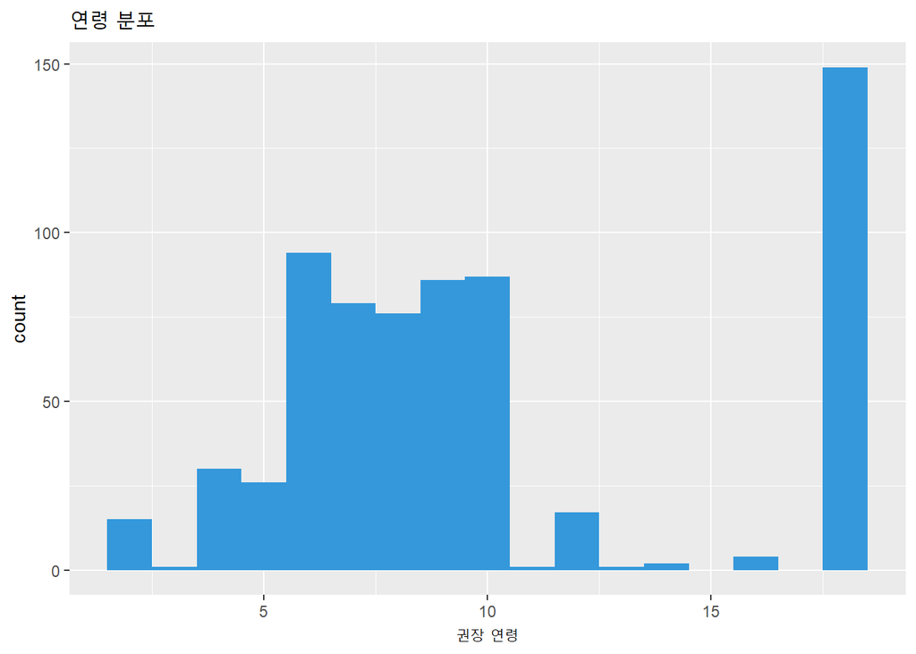

```r
ggplot(df, aes(x = age)) +
  geom_histogram(binwidth = 1, fill="#3498db") +
  labs(title="연령 분포", x="권장 연령")
```

- 연령 정보는 2세~18세에 분포하며, 특히 **6~10세 아동용**과 **18세 이상 성인용**에서 뚜렷한 두 개의 밀집 구간이 나타남

```r
df %>%
  filter(!is.na(release_date)) %>%
  mutate(year = lubridate::year(release_date)) %>%
  count(year)
```

```
## # A tibble: 14 × 2
##     year     n
##    <dbl> <int>
##  1  2002     1
##  2  2010     1
##  3  2013     1
##  4  2015     3
##  5  2016     1
##  6  2017     4
##  7  2018     5
##  8  2019     3
##  9  2020    12
## 10  2021    16
## 11  2022    36
## 12  2023    74
## 13  2024   268
## 14  2025   243
```

- 레고 제품 출시일은 대부분 2020년이후 증가함 -> **현재 LEGO 공식 사이트에서 판매되는 제품 중심 데이터**라 최근 출시 제품이 과대표집되는 구조적 특성 때문으로 보임
- 출시연도가 최근에 집중되어 있다는 점에서 LEGO가 **최근 몇 년 간 어떤 제품 전략을 강화해왔는지 탐색할 필요성**을 느낌
- 이러한 패턴을 바탕으로 **레고는 최근 어떤 제품 전략을 사용하고 있는가?**라는 질문이 자연스럽게 떠오름

# **Resonance**

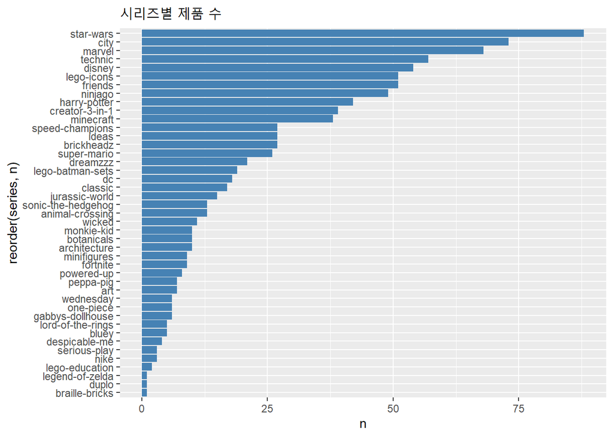

```r
df %>%
  count(series, sort = TRUE) %>%
  ggplot(aes(x = reorder(series, n), y = n)) +
  geom_col(fill = "steelblue") +
  coord_flip() +
  labs(title = "시리즈별 제품 수")
```

- LEGO 제품군은 시리즈 간 제품 수 변동 폭이 매우 큼
- LEGO의 제품 전략이 **미디어 IP 기반의 대형 프랜차이즈 중심구조**임을 확인할 수 있음(Star Wars, Marvel, Disney, Harry Potter 등이 상위권을 차지)
- 반대로 Duplo, Braille Bricks 등은 **특정 목적(유아용, 교육용)**을 가진 틈새 시리즈라 전체 물량은 적지만 특정 타깃군을 위한 전략적 제품군일 가능성이 있음

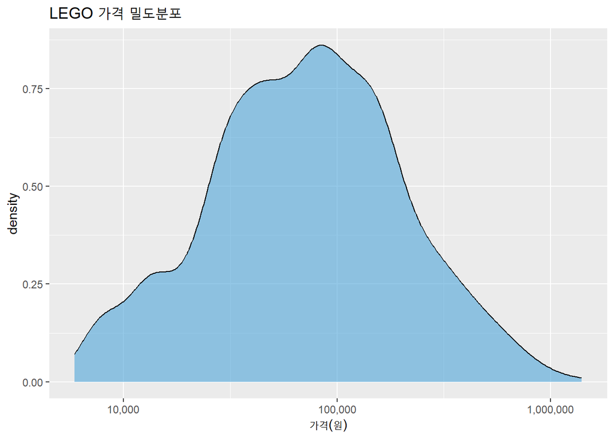

```r
ggplot(df, aes(x = price)) +
  geom_density(fill="#4EA5D9", alpha=0.6) +
  scale_x_log10(labels = label_comma()) +
  labs(
    title = "LEGO 가격 밀도분포",
    x = "가격(원)"
  )
```

- **가격이 여러 크기의 제품군(저가, 중가, 고가)로 계층화**되어 있음
- 특히 고가/초고가(40만~100만) 영역이 상당히 존재하며 이는 일반 아동 소비자 외의 **또 다른 타깃층이 있다는 신호처럼 보임**

```r
series_pieces_age <- df %>%
  filter(!is.na(age)) %>%      # 연령 정보 있는 제품만 분석
  group_by(series) %>%
  summarise(
    n = n(),
    mean_pieces = mean(pieces),
    max_pieces = max(pieces),
    mean_age = round(mean(age), 1),
    min_age = min(age)
  ) %>%
  arrange(desc(mean_pieces))

series_pieces_age %>% head(10)
```

```
## # A tibble: 10 × 6
##    series                n mean_pieces max_pieces mean_age min_age
##    <chr>             <int>       <dbl>      <dbl>    <dbl>   <dbl>
##  1 lord-of-the-rings     5       3008        6167     16.4      10
##  2 serious-play          3       2596.       5100      6         6
##  3 legend-of-zelda       1       2500        2500     18        18
##  4 lego-icons           44       2391.      10001     17.8       9
##  5 ideas                22       2090.       3955     18        18
##  6 art                   4       1866.       3091     18        18
##  7 architecture          9       1457.       3455     15.1      12
##  8 fortnite              2       1392.       2503     14        10
##  9 technic              46       1141.       3893     11.8       7
## 10 one-piece             6       1125.       3402     10.5       8
```

```r
large_sets_age <- df %>%
  filter(pieces >= 4000, !is.na(age)) %>%
  group_by(series) %>%
  summarise(
    n = n(),
    mean_age = round(mean(age), 1),
    min_age = min(age),
    max_age = max(age)
  ) %>%
  arrange(desc(n))

large_sets_age
```

```
## # A tibble: 7 × 5
##   series                n mean_age min_age max_age
##   <chr>             <int>    <dbl>   <dbl>   <dbl>
## 1 lego-icons            7     18        18      18
## 2 harry-potter          3     16.7      16      18
## 3 star-wars             3     17.3      16      18
## 4 lord-of-the-rings     2     18        18      18
## 5 disney                1     18        18      18
## 6 marvel                1     18        18      18
## 7 serious-play          1      6         6       6
```

- 4000조각 이상의 초대형 세트는 대부분 **평균 연령 16~18세 이상의 성인 타깃 제품군**
- 즉, LEGO의 **초대형/프리미엄 세트는 거의 전적으로 성인 취미층/수집가층**에게 맞춰져 있음

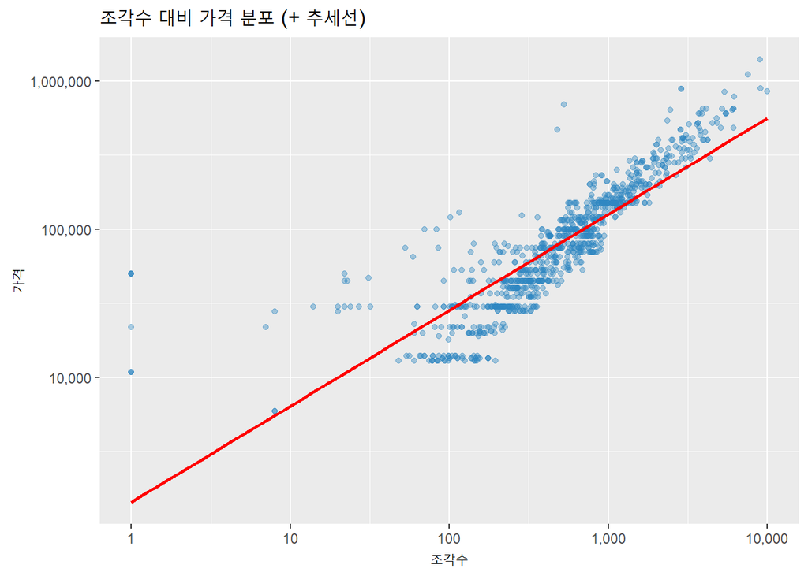

```r
df_pp <- df %>%
  mutate(price_per_piece = price / pieces) %>%
  filter(is.finite(price_per_piece))   # 0 또는 NA 제거
ggplot(df_pp, aes(x = pieces, y = price)) +
  geom_point(alpha = 0.4, color = "#2E86C1") +
  geom_smooth(method = "lm", se = FALSE, color = "red", size = 1) +
  scale_x_log10(labels = scales::comma) +
  scale_y_log10(labels = scales::comma) +   # 🔥 가격축 라벨 보기 좋게 수정
  labs(
    title = "조각수 대비 가격 분포 (+ 추세선)",
    x = "조각수",
    y = "가격"
  )
```

- **고피스 = 고가의 제품이고, 이는 성인 타깃의 구조를 볼 수 있음**
- 따라서 LEGO가 단순한 어린이 장난감 업체가 아니라, **성인 취미/ 콜렉터 시장을 전략적으로 확장해온 기업**이라는 강력한 증거가 될 수 있음

# **Insight**

`-`그렇다면 LEGO는 언제부터, 왜 성인 시장에 집중하기 시작했는가?

| Insight | 문제 상황(관찰) | 원인 분석 | 외부 뉴스·공시 근거 | 결론 |
| --- | --- | --- | --- | --- |
| **1. 2020년 전후가 전환점: 18+ 성인용 라인 등장** | 출시 연도가 2020년 이후로 급증(코로나 펜데믹으로 인해 새로운 전략 필요) | LEGO가 2020년 공식적으로 성인용 라인 도입 | - BrickFanatics: 2020년 “Adults Welcome” 캠페인 시작 - LEGO 공식: 18+는 “성인을 위한 프리미엄 세트”라고 명시 | **성인 공략 전략은 2020년 전후를 기점으로 본격화됨** |
| **2. 성인 팬층이 가장 빠르게 성장** | 고피스·고가 세트가 대부분 성인 연령대에 해당 | 성인 고객의 객단가↑, 소비 속도↑ | - LEGO 임원 인터뷰: 성인 매출 비중 5%→20% 증가 (BrickFanatics) | **성인은 높은 객단가 + 빠른 성장의 핵심 고객군** |
| **3. 완구 시장 정체 속 성인(Kidult) 시장 급성장** | 초대형 세트가 Star Wars, Icons 등 성인 취향 IP에 집중 | 글로벌 키덜트 시장 확대 → LEGO는 고가 라인 확장 | - 파이낸셜 타임스 기사: 미국 완구 시장 성인 구매자 18% 차지 - LEGO 매출 2024 상반기 +13% 증가(성인 라인 견인) | **레고는 키덜트 트렌드를 활용해 성장한 대표 기업** |
| **4. AFOL(Adult Fans of LEGO) 팬덤이 LEGO의 브랜드 자산** | Ideas·Icons 등 성인 취향 시리즈 증가 | 성인 팬덤이 제품 기획·콘텐츠 확산에 직접 관여 | - AFOL 연구: 성인은 “공동 디자이너·마케터” 역할 - LEGO Ideas: 팬 아이디어 실제 제품화 사례 다수 | **성인 팬덤은 레고의 생산·홍보·브랜딩을 함께 만드는 핵심 파트너** |

# **Problem**

확인된 패턴(성인 타깃 제품 증가/고가 제품 집중/IP 몰림)을 기반으로 **레고가 앞으로 어떤 IP 시장/제품 전략을 선택해야 더 성장할 수 있는가?**

## `-` **문제 상황**

### 1. 시장 변화

- 아동 완구 시장 성장률: **정체**
- 성인 취미·키덜트 시장: **폭발적 성장 (미국 매출 비중 18%)**
- LEGO 내부에서도: 성인 매출 비중 **5% → 20%** (BrickFanatics 인터뷰)
- 팬덤 기반 소비(굿즈·세계관·디지털 경험)가 시장의 중심으로 이동

### 2. 데이터에서 드러난 구조 변화

| 분석 항목 | 내부 데이터에서 확인된 패턴 |
| --- | --- |
| **출시 연도** | 2020년 이후 제품 수 급증 → 성인용 18+ 전략과 동일 시점 |
| **연령대** | 6–10세 아동용 + **18+ 성인용**의 “이중 피크” |
| **고가 제품** | 4000+ 초대형 세트의 평균 연령 16–18세 (성인 중심) |
| **IP 구조** | Star Wars·ICONS·LOTR 등 “성인 취향 IP”가 초대형 라인 절대 다수 |
| **가격 구조** | 저가·중가·고가가 명확히 분리된 계층 구조 |

**-> LEGO는 이미 성인·고가·IP 중심 전략으로 구조적 전환이 되었음**

### 3. 경쟁 환경 변화

| 트렌드 | 설명 |
| --- | --- |
| **OTT·애니·웹툰 시장의 폭발적 성장** | 넷플릭스·아마존·웹툰 기반 글로벌 팬덤 증가 |
| **게임 시장의 압도적 성장** | 스트리머·유튜브·e스포츠 중심, 팬덤·스토리 강함 |
| **K-콘텐츠 글로벌 파급력** | 음악·애니·드라마가 Z세대·α세대 핵심 문화 |
| **IP 중심 소비 강화** | 소비자들은 “세계관 기반 상품”에 높은 지불 의사 |

**-> 트렌드가 바뀌어 가면서 레고의 차세대 성장동력을 위한 콘텐츠·제품·경험에 있어서 새로운 전략이 필요해 보임**

## `-` **차세대 전략**

### 1. 글로벌 게임 IP 대확장 (데이터·팬덤 기반)

| 게임 IP | 공략 이유 | LEGO 활용 가치 |
| --- | --- | --- |
| **Elden Ring** | GOTY·세계적 팬덤 | 보스전·성채 구조물 (8000pcs ICONS급) |
| **Baldur’s Gate 3** | 스토리·파티 기반 팬덤 | 캠프·캐릭터팩 |
| **Genshin / Star Rail** | K-콘텐츠와 동일 소비층 | 도시·성당·던전 디오라마 |
| **Hollow Knight** | 인디 대표작 | White Palace 미니 디오라마 |
| **Roblox** | 창작자 생태계 = LEGO Ideas 구조 | 크리에이터팩, UGC 연동 |

### 2. K-콘텐츠 라인 신설 (K-POP × 애니 × OTT)

| K-IP | 특징 | 레고화 예시 |
| --- | --- | --- |
| **KPOP Demon Hunters (케데헨)** | K팝 × 애니 세계관 | MV 세트 / 캐릭터팩 / 디오라마 |
| **오징어게임** | 전세계 메가히트 | 게임장 시리즈 |
| **스위트홈 / 지옥** | 괴수·액션·건물 구조 | 괴수전 대형세트 |
| **무빙 / DP** | 글로벌 OTT 성공 | 도시형 ICONS 라인 |
| **BTS·IVE·aespa** | 세계 최대 음악 팬덤 | 무대 세트 / 뮤비 시리즈 |

### 3. 글로벌 애니/웹툰 IP 확장( Webtoon × Anime × OTT 혼합 전략)

| IP | 플랫폼 | LEGO화 포인트 |
| --- | --- | --- |
| **ARCANE** | Netflix | 도시·기계·세계관 구조물 |
| **SPY×FAMILY** | 일본·글로벌 | 학교·첩보 미션 |
| **귀멸의 칼날** | 글로벌 인기 | “기둥 시리즈” |
| **주술회전** | 일본 팬덤 최강 | 영역전개 기믹 |
| **나 혼자만 레벨업** | K웹툰 세계화 | 던전·보스 라인 |

### 4. 실물 + 게임 + 메타버스 통합(Z·α세대 소비 방식에 대응한 경험형 LEGO)

| 전략 요소 | 구체 내용 | 기대 효과 |
| --- | --- | --- |
| **LEGO Metaverse 구축 (Roblox / UEFN 기반)** | Roblox·UEFN 내 공식 LEGO 월드 구축 | Z·α세대 신규 유입 / 글로벌 플레이 경험 확대 |
| **실물 ↔︎ 디지털 양방향 연동** | 실물 LEGO 구매 시 게임 내 아이템·스킨 제공 | 실물·디지털의 동시 매출 상승 / 충성도 강화 |
| **Metaverse 창작물 → 실물 제품화** | 게임 내 제작물을 LEGO Ideas와 연동해 제품화 | 창작 생태계 확대 / 팬덤 주도 개발 구조 |
| **LEGO Avatar·UGC 생태계 강화** | 아바타 꾸미기, 사용자 제작 스킨, 디오라마 공유 | 지속 사용 시간 증가 / 커뮤니티 활성화 |
| **크로스 플랫폼 이벤트** | 영화·게임·K콘텐츠 IP 콜라보 이벤트 개최 | IP 팬덤 흡수 / 글로벌 홍보 극대화 |

## `-` **최종 결론**

- 레고는 기존 포트폴리오를 넘어서 **게임·K-콘텐츠·애니·웹툰·OTT·메타버스를 모두 포괄하는 차세대 멀티버스 IP 전략이 필요함**
- **이 전략은 성인 시장(18+)과 Z·α세대를 동시에 확보하고, 레고의 중장기 성장동력으로 작동할 것으로 예상됨**